# Dynamic Models

Ecological Forecasting Workshop, Cape Town, July 2025

Murray Christian

## What is a dynamic model?

Dynamic models describe a function implicitly by describing the *change* that governs it.

Differential equations in continuous time

- “differential equation”: an equation containing an unknown function and its derivative(s), e.g.
- $$\frac{dN}{dt} = rN \hspace{5pt} \text{ or } \hspace{5pt} \frac{1}{N}\frac{dN}{dt} = r,$$
  for constant $r$.
- “solving” differential equations means finding the unknown function analytically or numerically, e.g.
  $$N(t) = N_0e^{rt} \hspace{10pt} \text{ for } t \geq 0$$

Difference equations in discrete time

- “difference equation”: specifies a function at $t+1$ in terms of value at $t$
- e.g.
  $$N_{t+1} = N_t + rN_t = (1 + r)N_t$$
- or generally
  $$N_{t+1} = F(N_t)$$
  for some function $F$
- numerical simulation of difference equations is straightforward

## Population growth

Two classic dynamic models describe different population dynamics

- Exponential growth
  $$\frac{dN}{dt} = rN.$$
- Logistics population model with density-dependent dynamics
  $$\frac{dN}{dt} = rN\left(1 - \frac{N}{K}\right),$$

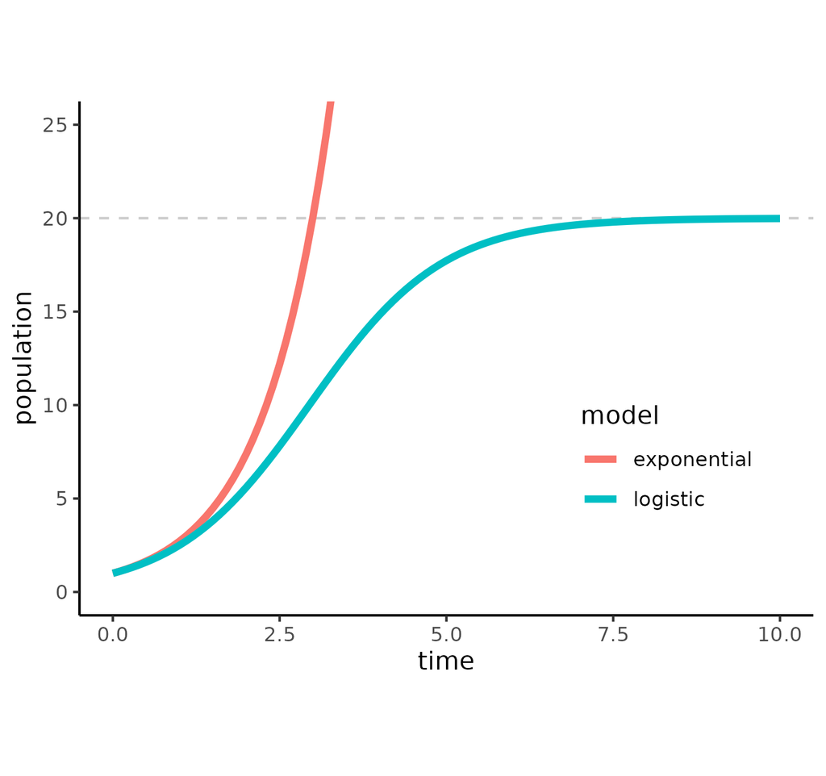

Per-capita rate of change $\frac{1}{N}\frac{dN}{dt}$ is very simple in both, but dynamics are highly non-linear.

# Intuition building

## Dynamic models in discrete time

Let’s start at the simplest possible dynamic models in discrete time

$$y_{t+1} = y_t$$

The only thing the dynamics depend on is the initial condition $y_1$:

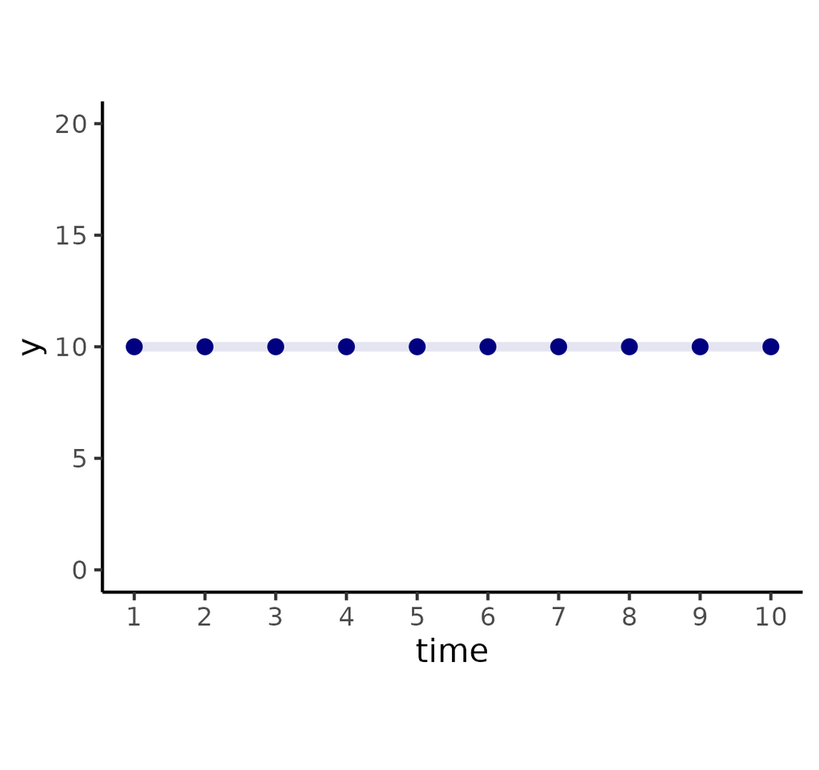

## Dynamic models in discrete time

As an aside, things get a bit more interesting if we move from a deterministic to a stochastic model

$$y_{t+1} = y_t + \epsilon_t, \hspace{10pt} \text{ where } \epsilon_t \sim \text{Normal}(0, \sigma^2)$$

The result is known as a random walk:

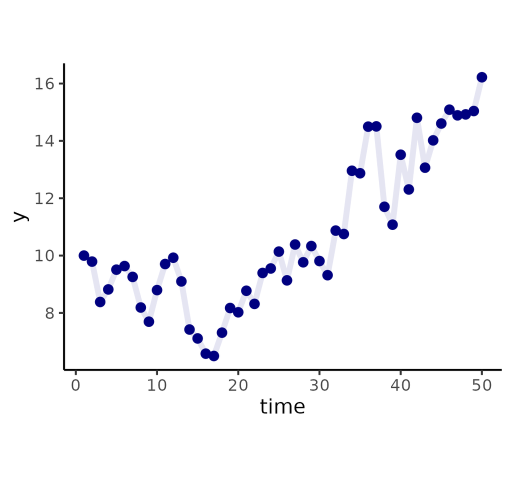

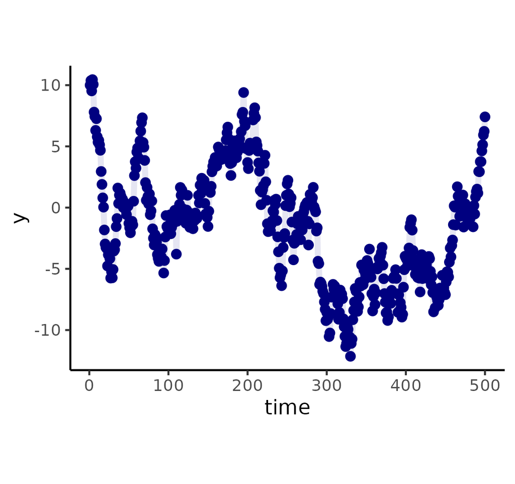

## Dynamic models in discrete time

Back to deterministic models, exponential growth/decline results from

$$y_{t+1} = \rho y_t \hspace{5pt} \text{ for } \rho > 0.$$

- Solve by iteration,
  - $y_2 = \rho y_1$,
  - $y_3 = \rho y_2 = \rho^2 y_1$,
  - …
- So
  $$y_{t+1} = \rho^t y_1,$$
  thus exponential growth ($\rho > 1$) or decline ($\rho < 1$).

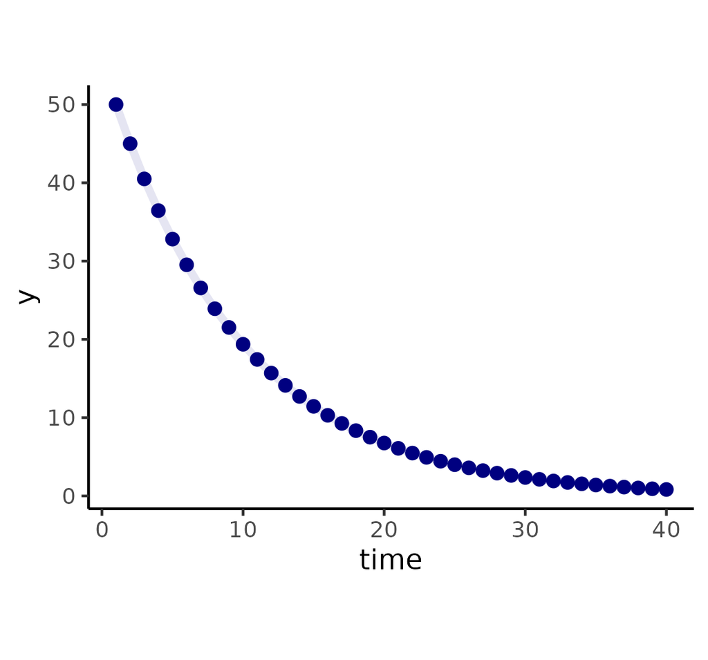

## Dynamic models in discrete time

Consider something slightly more complex:

$$y_{t+1} = \beta + \rho y_t.$$

How can we understand this equation?

- if $\beta > 0$ and $\rho > 1$, exponential growth
- long-run behaviour and equilibria
  - if $\lim_{t \rightarrow \infty}y_t = l$ exists, $l = \beta/(1-\rho)$
  - alternatively, subtract $y_t$ from both sides to get
    $$\Delta y_t = y_{t+1} - y_t = \beta + (\rho - 1) y_t$$
  - equilibrium if $\Delta y_t=0$, at $l = \beta/(1-\rho)$
- the equilibrium is only sensible if $\beta > 0$ and $0 < \rho < 1$.

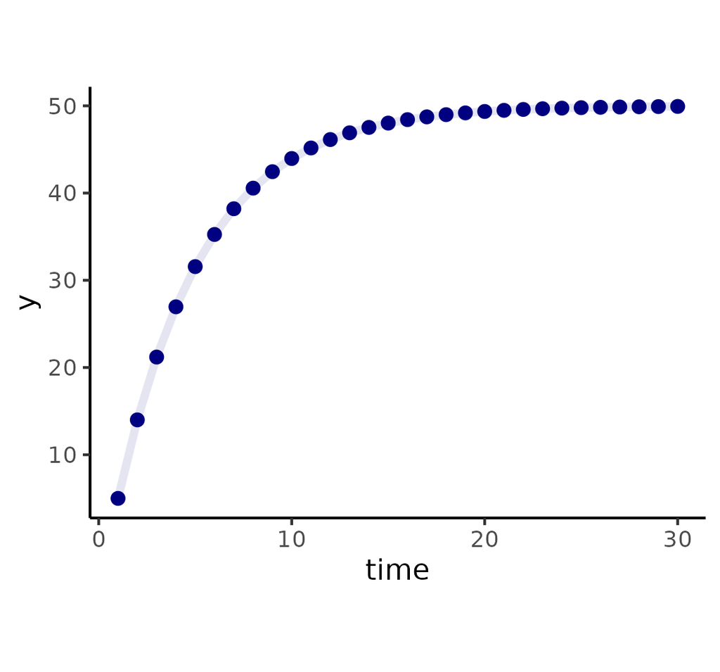

## Dynamic models in discrete time

If we push things just one bit further, all hell breaks loose!

- exponential growth: $y_{t+1} = \rho y_t$ where $\rho = y_{t+1}/y_t$ is the *growth rate*
- for density dependence,
  - $\rho = \rho(y_t)$, for example $\rho(y_t) = r\left(1 - \frac{y_t}{K}\right)$
  - $$\rho(y_t) \approx \left\{
    \begin{align}
    r & \hspace{5pt} \mbox{ if } y_t << K \\
    0 & \hspace{5pt} \mbox{ if } y_t \approx K.
    \end{align} \right.$$
- we arrive at a non-linear equation
  $$y_{t+1} = ry_t\left(1 - \frac{y_t}{K}\right)$$
- we can remove $K$ by scaling, $x_t = y_t/K$, giving one parameter
  $$x_{t+1} = rx_t(1-x_t)$$

## Dynamic models in discrete time

The ‘logistic map’ $x_{t+1} = rx_t(1-x_t)$ has incredibly rich dynamics as $r$ varies! The dynamics at various value of $r$ are explored in the interactive `logistic_map` app, which you can run from `run_apps.R`.

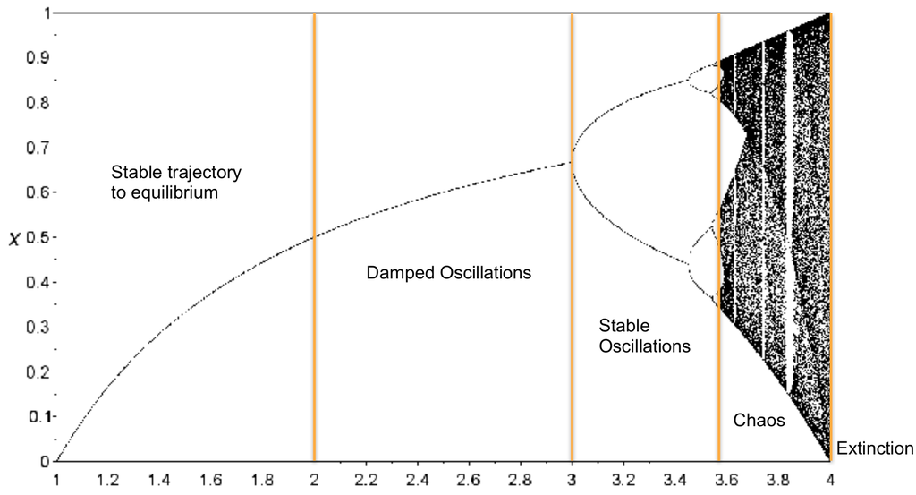